# InstaCart Exploratory Analysis

April Leclair, Daniel Ochoa, Hoang Anh Thai Vu, Qiuhan Sun

This file provides some exploratory analysis of the InstaCart data.

# Reading in the data

```r
orders <- read.csv("../Source/orders.csv") %>%
  mutate(order_dow = as.character(recode(order_dow, `0`="Sunday", `1`="Monday", `2`="Tuesday",
                            `3`="Wednesday", `4`="Thurday", `5`="Friday", `6`="Saturday")))
prior <-
  orders %>%
  filter(eval_set == "prior") %>%
  mutate(order_dow = as.character(recode(order_dow, `0`="Sunday", `1`="Monday", `2`="Tuesday",
                            `3`="Wednesday", `4`="Thurday", `5`="Friday", `6`="Saturday")))

trial <-
  orders %>%
  filter(eval_set == "trial") %>%
  mutate(order_dow = as.character(recode(order_dow, `0`="Sunday", `1`="Monday", `2`="Tuesday",
                            `3`="Wednesday", `4`="Thurday", `5`="Friday", `6`="Saturday")))
test <-
  orders %>%
  filter(eval_set == "test") %>%
  mutate(order_dow = as.character(recode(order_dow, `0`="Sunday", `1`="Monday", `2`="Tuesday",
                            `3`="Wednesday", `4`="Thurday", `5`="Friday", `6`="Saturday")))

products <- read_csv("../Source/products.csv")

departments <- read_csv("../Source/departments.csv")

aisles <- read_csv("../Source/aisles.csv")
```

Let’s start off looking at some rows in the order data.

```r
names(orders)
```

```
## [1] "order_id"               "user_id"
## [3] "eval_set"               "order_number"
## [5] "order_dow"              "order_hour_of_day"
## [7] "days_since_prior_order"
```

```r
names(products)
```

```
## [1] "product_id"    "product_name"  "aisle_id"      "department_id"
```

```r
names(departments)
```

```
## [1] "department_id" "department"
```

```r
names(products)
```

```
## [1] "product_id"    "product_name"  "aisle_id"      "department_id"
```

```r
head(orders, 12)
```

```
##    order_id user_id eval_set order_number order_dow order_hour_of_day
## 1   2539329       1    prior            1   Tuesday                 8
## 2   2398795       1    prior            2 Wednesday                 7
## 3    473747       1    prior            3 Wednesday                12
## 4   2254736       1    prior            4   Thurday                 7
## 5    431534       1    prior            5   Thurday                15
## 6   3367565       1    prior            6   Tuesday                 7
## 7    550135       1    prior            7    Monday                 9
## 8   3108588       1    prior            8    Monday                14
## 9   2295261       1    prior            9    Monday                16
## 10  2550362       1    prior           10   Thurday                 8
## 11  1187899       1    train           11   Thurday                 8
## 12  2168274       2    prior            1   Tuesday                11
##    days_since_prior_order
## 1                      NA
## 2                      15
## 3                      21
## 4                      29
## 5                      28
## 6                      19
## 7                      20
## 8                      14
## 9                       0
## 10                     30
## 11                     14
## 12                     NA
```

Quick Overview of the data:

order_id is a unique value given to each order.  
user_id is a unique value given to each user.  
eval_set refers the set of data that this row belongs to. This attribute has three levels: “prior”, “train”, and “test”. The model should be trained on “prior”, validated on “train” and ran on “test” for submission.  
order_number refers to the nth order that this this user had made.  
order_dow refers to the day of the week, 0 being Sunday (not confirmed), that the order was made.  
order_hour_of_day refers to the hour of the day that the order was made.  
days_since_prior_order refers to the numnber of days that have passed since this user last made an instaCart order.

We can see from the 12 rows above that the rows are ordered according to user_id and within users is ordered according order_number.

Let’s start trying to understand the data:

# When Do People Order?

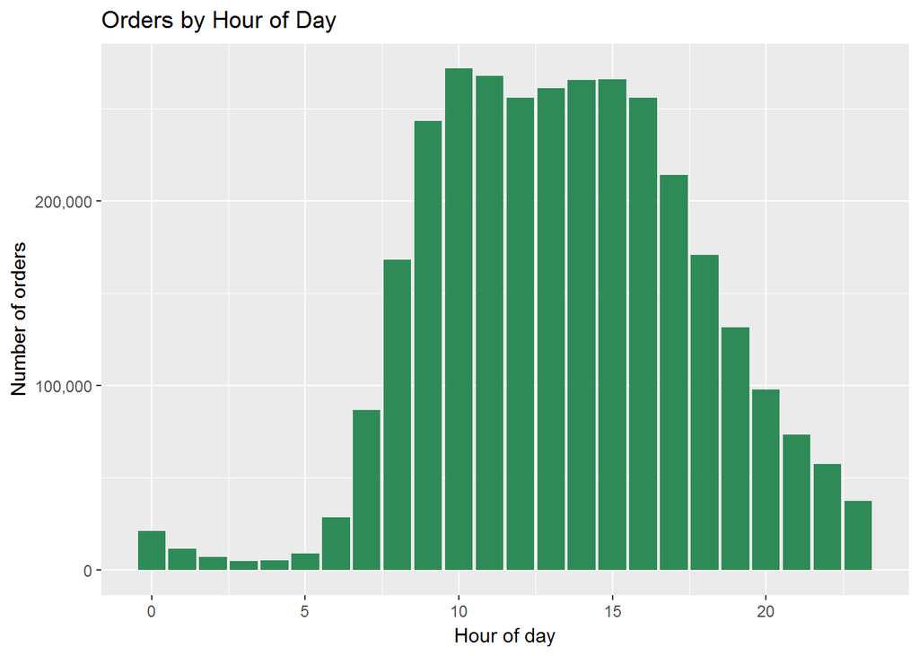

```r
plot1 <-
  prior %>%
  ggplot(aes(x=order_hour_of_day)) +
  geom_histogram(stat="count", fill="seagreen4") +
  scale_y_continuous(labels = comma) +
  labs(x="Hour of day", y="Number of orders", title="Orders by Hour of Day")
plot1
```

It appears that the majority of orders are made between 10am and 4pm.

# When Do People Order - Orders by Hour of Day by Day of the Week & Days Since Prior Order

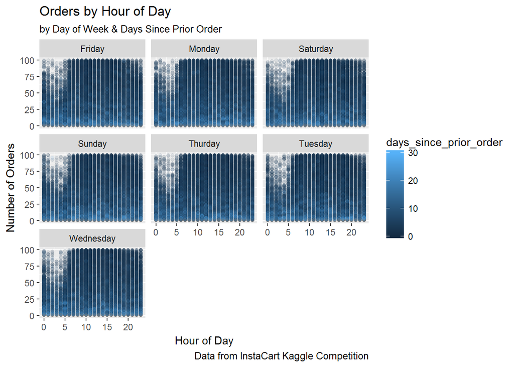

```r
plot2 <-
  prior %>%
  ggplot(aes(x=order_hour_of_day, y=order_number)) +
  geom_point(aes(color=days_since_prior_order), alpha = 0.10) +
  facet_wrap(~order_dow) +
  labs(x="Hour of Day", y="Number of Orders",
       title="Orders by Hour of Day", subtitle="by Day of Week & Days Since Prior Order",
       caption="Data from InstaCart Kaggle Competition")
plot2
```